# Lecture 4 — Obtaining the Posterior: Grid Approximation & MCMC (Ch. 6 & 7)

Author

Johnny van Doorn

Published

June 10, 2026

By the end of this lecture, you will be able to:

- Explain why conjugate models are limited and when you must go beyond them
- Implement **grid approximation** to obtain posterior samples for non-conjugate models
- Explain the intuition behind **Markov Chain Monte Carlo (MCMC)** and the Metropolis algorithm
- Read the key MCMC convergence diagnostics (trace plots, $\hat R$, effective sample size)
- Use posterior samples — regardless of how they were obtained — to compute summaries

**Recommended Reading:** *Bayes Rules!* Chapters 6 (approximating the posterior) and 7 (MCMC under the hood). Suggested exercises: Ch. 6 — 2, 3, 8; Ch. 7 — 4, 9.

**On the exam you don’t need to implement samplers by hand or use Stan, but you should understand the intuition and be able to interpret diagnostics.**

# Review: Four Ingredients of a Bayesian Analysis

Every Bayesian model is built on the same four components, regardless of model complexity.

**The four ingredients**

1. **Prior model** — beliefs about parameter $\theta$ before seeing data: $f(\theta)$
2. **Data model (likelihood)** — how data arise given the parameter: $f(y \mid \theta)$
3. **Likelihood function** — the same expression viewed as a function of $\theta$ with $y$ fixed: $L(\theta \mid y) \propto f(y \mid \theta)$
4. **Posterior model** — updated beliefs after seeing data: $f(\theta \mid y) \propto f(\theta) \cdot L(\theta \mid y)$

The three conjugate families from last lecture:

| Likelihood | Prior | Posterior |
| --- | --- | --- |
| Binomial$(n, \theta)$ | Beta$(\alpha, \beta)$ | Beta$(\alpha+y,\;\beta+n-y)$ |
| Poisson$(\lambda)$ | Gamma$(s, r)$ | Gamma$(s+\sum y_i,\; r+n)$ |
| Normal$(\mu, \sigma^2)$, $\sigma$ known | Normal$(\mu_0, \tau^2)$ | Normal$(\mu_\text{post}, \sigma^2_\text{post})$ |

**Today** we ask: what happens when the model is *not* conjugate, or when the posterior simply has no closed form? We turn to numerical approximations — grid approximation and MCMC.

# Running Example: Dutch Railways

We will use one running example throughout this lecture, starting with a conjugate set-up and then breaking it.

**Scenario**

You are a data analyst for the Dutch Railway Service (NS). Your task: model the **monthly rate of signal failures** on a 10 km stretch of track.

- Parameter: $\lambda =$ mean failures per month
- Likelihood: $Y_i \mid \lambda \overset{\text{iid}}{\sim} \text{Poisson}(\lambda)$
- Prior: Gamma(2, 0.5) — failures are relatively rare, modest prior certainty (mean = 4)

```r
library(bayesrules)

# Observed 4 months: y = (2, 0, 3, 1)
y <- c(2, 0, 3, 1)

# Posterior: Gamma(s + sum(y), r + n) = Gamma(8, 4.5)
s_post <- 2 + sum(y)
r_post <- 0.5 + length(y)
cat("Posterior: Gamma(", s_post, ",", r_post, ")\n")
```

```
Posterior: Gamma( 8 , 4.5 )
```

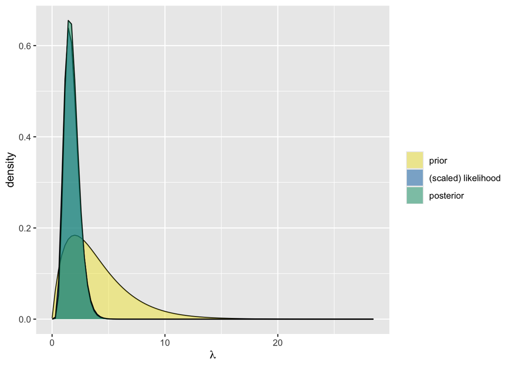

```r
plot_gamma_poisson(shape = 2, rate = 0.5, sum_y = sum(y), n = length(y))
```

```r
summarize_gamma_poisson(shape = 2, rate = 0.5, sum_y = sum(y), n = length(y))
```

| model | shape | rate | mean | mode | var | sd |
| --- | --- | --- | --- | --- | --- | --- |
| prior | 2 | 0.5 | 4.000000 | 2.000000 | 8.0000000 | 2.8284271 |
| posterior | 8 | 4.5 | 1.777778 | 1.555556 | 0.3950617 | 0.6285394 |

So far so familiar — the Gamma–Poisson is conjugate, and the posterior is a clean Gamma(8, 4.5). But what if the engineer’s prior beliefs *aren’t* Gamma-shaped? Maybe she’s confident that $\lambda$ lies in $[1, 5]$ and is unwilling to commit to a particular shape within that range. Or maybe she has two competing hypotheses about the maintenance regime that suggest a bimodal prior. The conjugacy trick breaks — but the mathematics

$$f(\lambda \mid y) \propto f(\lambda) \cdot L(y \mid \lambda)$$

still holds. We just can’t read off the answer in closed form. That’s the puzzle the rest of this lecture solves.

# Beyond Conjugacy: Grid Approximation & MCMC

Conjugate models require prior and likelihood to match. Real research often involves:

- Multiple unknown parameters
- Non-standard prior shapes (truncated, mixture)
- Complex hierarchical models

The good news: $f(\theta \mid y) \propto f(\theta) \cdot L(y \mid \theta)$ always holds. We just need numerical methods to compute usable summaries.

## Grid Approximation

1. Define a grid: $\theta_1, \ldots, \theta_K$
2. Evaluate unnormalised posterior at each point: $u_i = f(\theta_i) \cdot L(y \mid \theta_i)$
3. Normalise: $\hat{f}(\theta_i \mid y) = u_i / \sum_j u_j$
4. Sample from the grid with probabilities proportional to $\hat{f}$

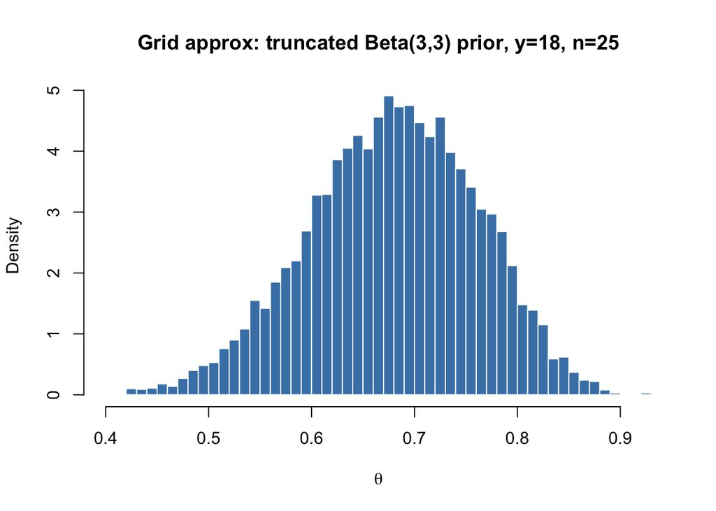

```r
# Non-conjugate example: Beta(3,3) prior truncated to [0.4, 1]
theta_grid <- seq(0, 1, length.out = 2000)

prior      <- dbeta(theta_grid, 3, 3) * (theta_grid >= 0.4)
likelihood <- dbinom(18, size = 25, prob = theta_grid)

unnorm         <- prior * likelihood
posterior_grid <- unnorm / sum(unnorm)

theta_samples <- sample(theta_grid, size = 1e4,
                        replace = TRUE, prob = posterior_grid)

hist(theta_samples, breaks = 50, probability = TRUE,
     main = "Grid approx: truncated Beta(3,3) prior, y=18, n=25",
     xlab = expression(theta), col = "steelblue", border = "white")
```

```r
cat("Posterior mean:", round(mean(theta_samples), 3), "\n")
```

```
Posterior mean: 0.679
```

```r
cat("95% ETI: [", round(quantile(theta_samples, 0.025), 3),
    ",", round(quantile(theta_samples, 0.975), 3), "]\n")
```

```
95% ETI: [ 0.512 , 0.827 ]
```

**Limitation:** Grid points grow as $K^p$ with the number of parameters $p$. With 10 parameters and 100 grid points each, you need $100^{10} = 10^{20}$ evaluations — infeasible.

## MCMC — The Intuition

**Markov Chain Monte Carlo** draws samples from the posterior *without* computing the normalising constant.

**The island-hopping metaphor** (Metropolis algorithm)

A politician visits islands whose populations represent posterior density:

1. Propose a neighbouring island at random
2. If it’s bigger → always move
3. If it’s smaller → move with probability = (proposed / current population)
4. Otherwise → stay put

Long-run time spent on each island $\propto$ population — without ever needing the total.

### The acceptance rule

The metaphor becomes exact through the **acceptance probability**. Standing at the current value $\mu$, we propose a new value $\mu'$ from a (symmetric) proposal model and then accept the move with probability

$$\alpha = \min\!\left\{1,\; \frac{f(\mu')\,L(\mu' \mid y)}{f(\mu)\,L(\mu \mid y)}\right\}.$$

Here is the crucial trick. Divide the numerator and denominator by the intractable normalising constant $f(y)$ — it cancels:

$$\alpha = \min\!\left\{1,\; \frac{f(\mu' \mid y)}{f(\mu \mid y)}\right\}.$$

So the accept/reject decision depends only on the **ratio of (unnormalised) posterior plausibilities**, which is exactly what we *can* evaluate as $f(\mu)\,L(\mu \mid y)$. This is the whole reason MCMC escapes the normalising-constant problem that broke conjugacy.

**Two scenarios** — the “bigger / smaller island” rules made precise

- **Proposal at least as plausible** ($f(\mu' \mid y) \ge f(\mu \mid y)$): $\alpha = 1$, so we *always* move.
- **Proposal less plausible** ($f(\mu' \mid y) < f(\mu \mid y)$): move with probability $\alpha = f(\mu' \mid y) / f(\mu \mid y) < 1$. Bolder downhill jumps are accepted less often, so the chain still visits the tails occasionally but spends most of its time where the posterior mass is.

With a **symmetric** proposal — like the Uniform $\mu' \mid \mu \sim \text{Unif}(\mu - w, \mu + w)$ used in Exercises 7.4 and 7.9 — the proposal terms cancel and we get exactly the **Metropolis** rule above. Asymmetric proposals carry an extra factor $q(\mu \mid \mu')/q(\mu' \mid \mu)$ (the full Metropolis–**Hastings** rule).

## The Algorithm, Step by Step (Dutch Railways)

Let’s run the algorithm on our signal-failure data $y = (2, 0, 3, 1)$ with the Gamma(2, 0.5) prior. We already know the posterior is Gamma(8, 4.5), so we can hold the sampler up against the truth. The only ingredient we need is the **unnormalised** log-posterior, $\log\!\big[f(\lambda)\,L(\lambda \mid y)\big]$:

```r
y <- c(2, 0, 3, 1)

# Unnormalised log-posterior for the NS rate lambda
# (prior Gamma(2, 0.5)  x  Poisson likelihood)
log_post_ns <- function(lambda) {
  if (lambda <= 0) return(-Inf)                      # lambda must be positive
  dgamma(lambda, shape = 2, rate = 0.5, log = TRUE) +
    sum(dpois(y, lambda, log = TRUE))
}
```

### One iteration

Suppose the chain currently sits at $\lambda = 2$. One Metropolis step is exactly the three moves from the acceptance rule: **propose**, **score**, **decide**.

```r
set.seed(13)
current <- 2        # current chain location
width   <- 0.8      # proposal SD (symmetric Normal proposal -> Metropolis)

# STEP 1 — propose a nearby value
proposal <- rnorm(1, mean = current, sd = width)

# STEP 2 — acceptance probability = min(1, ratio of unnormalised posteriors)
alpha <- min(1, exp(log_post_ns(proposal) - log_post_ns(current)))

# STEP 3 — flip a coin: move with probability alpha, otherwise stay put
u        <- runif(1)
next_val <- if (u < alpha) proposal else current

cat("current    :", round(current, 3), "\n")
```

```
current    : 2
```

```r
cat("proposal   :", round(proposal, 3), "\n")
```

```
proposal   : 2.443
```

```r
cat("alpha      :", round(alpha, 3), "\n")
```

```
alpha      : 0.552
```

```r
cat("coin u     :", round(u, 3), if (u < alpha) " -> ACCEPT" else " -> reject", "\n")
```

```
coin u     : 0.39  -> ACCEPT
```

```r
cat("next value :", round(next_val, 3), "\n")
```

```
next value : 2.443
```

In this draw the proposal is a little *less* plausible than the current value, so $\alpha < 1$ — we only *might* move (Scenario 2 from the acceptance rule). The coin flip happens to fall below $\alpha$, so we accept. Had it landed above $\alpha$, the chain would have stayed at $\lambda = 2$ and recorded that value again.

### …and keep going

A full sampler just repeats that step a few thousand times, each iteration starting from wherever the previous one landed:

```r
run_mh <- function(width, start, n_iter) {
  lam <- numeric(n_iter)
  lam[1] <- start
  accepts <- 0
  for (t in 2:n_iter) {
    proposal <- rnorm(1, mean = lam[t - 1], sd = width)
    if (log(runif(1)) < log_post_ns(proposal) - log_post_ns(lam[t - 1])) {
      lam[t] <- proposal; accepts <- accepts + 1
    } else {
      lam[t] <- lam[t - 1]                            # rejected: stay put
    }
  }
  attr(lam, "accept_rate") <- accepts / (n_iter - 1)
  lam
}

set.seed(13)
chain <- run_mh(width = 0.8, start = 2, n_iter = 2000)
round(head(chain, 10), 3)        # the chain's first ten stops
```

```
 [1] 2.000 2.443 1.378 1.527 1.527 1.527 1.250 2.134 2.229 1.140
```

See how some values repeat? Those are the iterations where the proposal was rejected and the chain stayed where it was.

### A reusable trace-plot tool

To explore how the sampler behaves under different settings, here is a small helper. Vary the **proposal width**, the **starting value(s)**, the **number of chains**, and the **chain length**, and it returns the trace plot (the dashed line marks the true posterior mean, $8/4.5 \approx 1.78$):

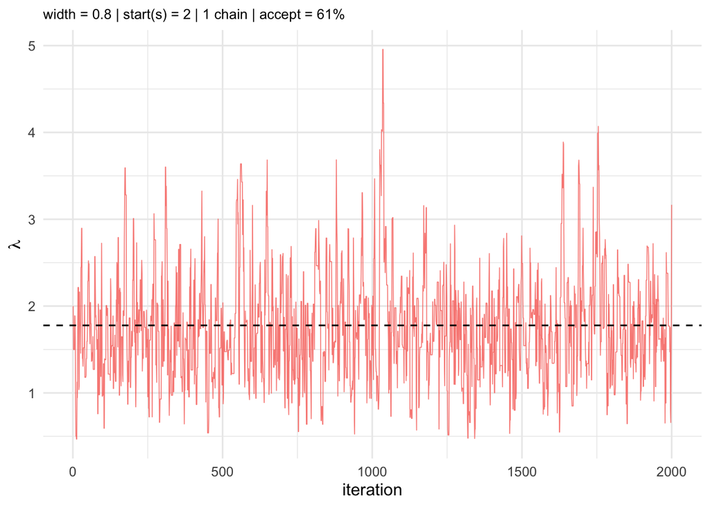

```r
trace_demo <- function(width = 0.8, starts = 2, n_chains = 1,
                       n_iter = 2000, seed = 1, title = NULL) {
  set.seed(seed)
  starts <- rep_len(starts, n_chains)                 # one start per chain
  chains <- lapply(starts, function(s) run_mh(width = width, start = s, n_iter = n_iter))
  acc    <- mean(sapply(chains, attr, "accept_rate"))

  df <- data.frame(
    iteration = rep(seq_len(n_iter), times = n_chains),
    lambda    = unlist(chains),
    chain     = factor(rep(seq_len(n_chains), each = n_iter))
  )
  if (is.null(title))
    title <- sprintf("width = %g | start(s) = %s | %d chain%s | accept = %.0f%%",
                     width, paste(round(starts, 2), collapse = ", "),
                     n_chains, if (n_chains > 1) "s" else "", 100 * acc)

  ggplot2::ggplot(df, ggplot2::aes(iteration, lambda, colour = chain)) +
    ggplot2::geom_line(linewidth = 0.3, alpha = 0.85) +
    ggplot2::geom_hline(yintercept = 8 / 4.5, linetype = "dashed") +
    ggplot2::labs(title = title, x = "iteration", y = expression(lambda)) +
    ggplot2::theme_minimal(base_size = 12) +
    ggplot2::theme(legend.position = if (n_chains > 1) "right" else "none",
          plot.title = ggplot2::element_text(size = 10))
}

# A healthy run
trace_demo(width = 0.8, starts = 2)
```

A well-tuned chain like this is the **“hairy caterpillar”**: it wanders rapidly around the dashed posterior mean with no trends and no long flat stretches.

## Diagnosing the Chain

In practice you let `brms` (which calls Stan) run the sampler and report the diagnostics automatically — but the ideas are identical whether the draws come from Stan or from the by-hand Metropolis sampler we build below. A Markov chain only *approximates* the posterior, so we must check that the approximation is trustworthy.

| Diagnostic | What it checks | Healthy sign |
| --- | --- | --- |
| **Trace plot** | does a single chain explore stably? | “hairy caterpillar”: white noise, no trends or flat runs |
| **Burn-in / warm-up** | early samples while the chain finds the posterior | discard them before summarising |
| **Parallel chains** | do independent chains agree? | several chains from different starts overlap |
| **Effective sample size** $N_{\text{eff}}$ | how many *independent* draws the dependent draws are worth | ratio $N_{\text{eff}}/N$ not too small (suspect if $< 0.1$) |
| **Autocorrelation** | how fast dependence between draws fades | drops to ~0 within a few lags |
| **$\hat R$ (R-hat)** | between-chain vs. within-chain variability | $\approx 1$; a value $> 1.05$ is a red flag |

### Visual diagnostics: trace plots

Now we can *see* the pathologies from Chapter 6.3 just by handing different settings to `trace_demo()`. A good trace plot looks like featureless white noise around the posterior mean; the troublesome ones drift slowly or stick.

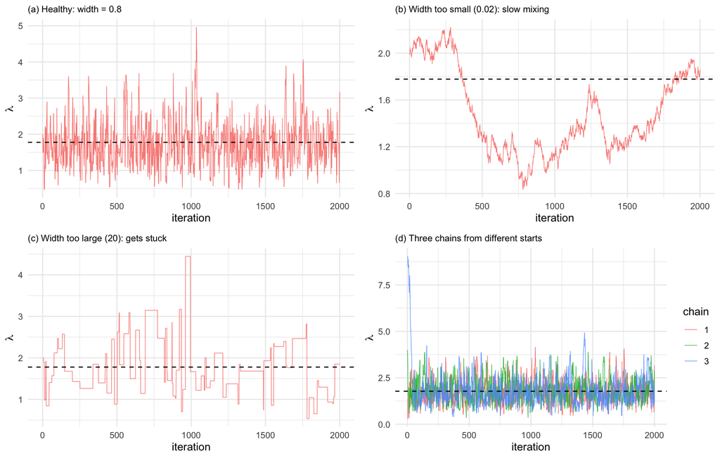

```r
library(gridExtra)
grid.arrange(
  trace_demo(width = 0.8,  starts = 2,            n_chains = 1,
             title = "(a) Healthy: width = 0.8"),
  trace_demo(width = 0.02, starts = 2,            n_chains = 1,
             title = "(b) Width too small (0.02): slow mixing"),
  trace_demo(width = 20,   starts = 2,            n_chains = 1,
             title = "(c) Width too large (20): gets stuck"),
  trace_demo(width = 0.8,  starts = c(0.3, 4, 9), n_chains = 3,
             title = "(d) Three chains from different starts"),
  ncol = 2
)
```

- **(a)** mixes well — rapid exploration around the posterior mean (~61% of proposals accepted).
- **(b)** a *too-small* width takes tiny steps: nearly every proposal is accepted (~99%), but the chain only inches along and is strongly autocorrelated — it has barely explored after 2,000 iterations.
- **(c)** a *too-large* width proposes wild values (often negative, always rejected), so only ~4% are accepted and the chain **sticks** for long stretches — the flat horizontal runs.
- **(d)** three chains launched from $\lambda \in \{0.3, 4, 9\}$ all migrate to the same band within a few dozen iterations (the **burn-in**) and then agree — strong evidence of convergence.

Try it live: call `trace_demo(width = ..., starts = ..., n_chains = ..., n_iter = ...)` with your own settings and watch the mixing — and the acceptance rate in each title — respond.

### Numerical diagnostics: effective sample size & R-hat

The numbers back up the picture. We run four longer parallel chains with `run_mh()` and hand them to `coda`:

```r
set.seed(2026)
raw <- lapply(c(0.5, 2, 5, 8), function(s) run_mh(width = 0.8, start = s, n_iter = 6000))
mc  <- mcmc.list(lapply(raw, function(ch) mcmc(ch[1001:6000])))   # drop 1,000 burn-in

N    <- 4 * 5000                       # total retained draws
ess  <- sum(effectiveSize(mc))         # effective sample size
rhat <- gelman.diag(mc)$psrf[1, 1]     # split-chain R-hat

cat("Total retained draws   :", N, "\n")
```

```
Total retained draws   : 20000
```

```r
cat("Effective sample size  :", round(ess), "\n")
```

```
Effective sample size  : 2830
```

```r
cat("Eff. sample-size ratio :", round(ess / N, 3), "  (suspect if < 0.1)\n")
```

```
Eff. sample-size ratio : 0.142   (suspect if < 0.1)
```

```r
cat("R-hat                  :", round(rhat, 4), "  (red flag if > 1.05)\n")
```

```
R-hat                  : 1.0007   (red flag if > 1.05)
```

```r
cat("Lag-1 autocorrelation  :", round(acf(raw[[1]][1001:6000], plot = FALSE)$acf[2], 3), "\n")
```

```
Lag-1 autocorrelation  : 0.728
```

Here the ratio sits above 0.1 and $\hat R \approx 1$, so we trust the approximation. The moderate lag-1 autocorrelation is expected for a random-walk Metropolis sampler — exactly what a better-tuned proposal (Exercise 7.4) or a smarter sampler such as Stan’s would reduce, raising the effective sample size.

### The autocorrelation plot

*Bayes Rules!* inspects chains with the **`bayesplot`** package — `mcmc_trace()` for trace plots, `mcmc_dens_overlay()` for the parallel-chain densities, and **`mcmc_acf()`** for the autocorrelation plot (the book’s Figures 6.15–6.16). The autocorrelation plot shows the correlation between chain values that are 1, 2, 3, … steps apart: in a healthy chain it drops to ~0 within a few lags; in a slow-mixing chain it lingers near 1. The same functions work on our hand-rolled draws, not just Stan output:

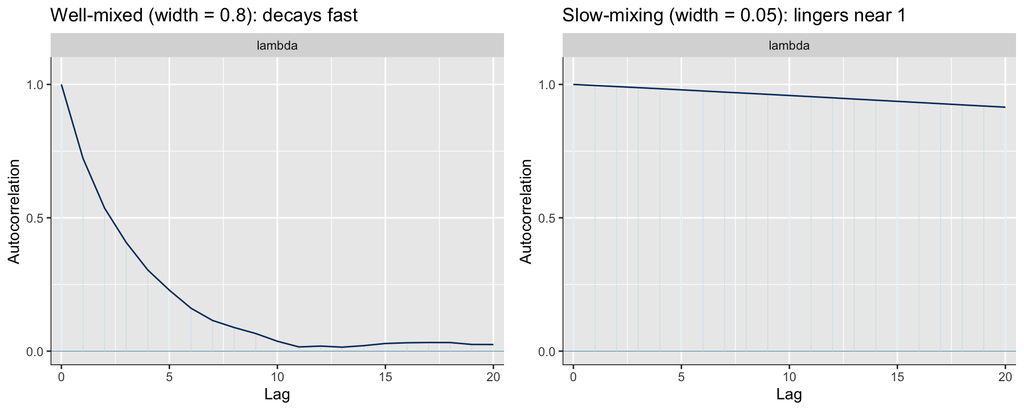

```r
library(bayesplot)

# One chain at each setting, packaged as a single-column "draws" matrix
acf_mat <- function(width, seed = 2026) {
  set.seed(seed)
  draws <- run_mh(width = width, start = 2, n_iter = 6000)[1001:6000]
  matrix(draws, ncol = 1, dimnames = list(NULL, "lambda"))
}

grid.arrange(
  mcmc_acf(acf_mat(0.8))  + ggtitle("Well-mixed (width = 0.8): decays fast"),
  mcmc_acf(acf_mat(0.05)) + ggtitle("Slow-mixing (width = 0.05): lingers near 1"),
  ncol = 2
)
```

On the left the autocorrelation falls away within a handful of lags — the draws quickly become “effectively independent,” giving a high effective sample size. On the right the tiny proposal width keeps consecutive draws almost identical, so the autocorrelation stays near 1 for many lags: lots of iterations, very little independent information. This is the visual signature behind a low $N_{\text{eff}}/N$ ratio.

## Using the Posterior Samples

Once you have MCMC draws, all posterior summaries work exactly the same as with conjugate samples:

```r
# theta_mcmc: any posterior sample (grid, MCMC, conjugate — identical workflow)
theta_mcmc <- theta_samples

mean(theta_mcmc)                        # posterior mean
```

```
[1] 0.6792933
```

```r
median(theta_mcmc)                      # posterior median
```

```
[1] 0.6818409
```

```r
mean(theta_mcmc > 0.6)                  # P(theta > 0.6 | y)
```

```
[1] 0.8314
```

```r
quantile(theta_mcmc, c(0.025, 0.975))   # 95% ETI
```

```
     2.5%     97.5%
0.5122436 0.8274137
```

# In-Class Exercises

## Exercise 1: Grid Approximation with a Truncated Prior

> A researcher believes the placebo effect rate is between 30% and 90%, and is otherwise uncertain. Prior: Beta(2,2) truncated to $[0.30, 0.90]$. Observed: 18 of 25 patients improve.

**Exercise**

1. Implement the grid approximation.
2. Compute the posterior mean and 95% ETI.
3. Compare to an untruncated Beta(2,2) — how much does the truncation matter here?

**Solution**

```r
theta_grid <- seq(0, 1, length.out = 5000)
y_obs <- 18; n_obs <- 25

# Truncated prior
prior_trunc <- dbeta(theta_grid, 2, 2) *
               (theta_grid >= 0.3 & theta_grid <= 0.9)
lik         <- dbinom(y_obs, n_obs, prob = theta_grid)
post_trunc  <- (prior_trunc * lik) / sum(prior_trunc * lik)
samp_trunc  <- sample(theta_grid, 1e4, replace = TRUE, prob = post_trunc)

# Untruncated
prior_full <- dbeta(theta_grid, 2, 2)
post_full  <- (prior_full * lik) / sum(prior_full * lik)
samp_full  <- sample(theta_grid, 1e4, replace = TRUE, prob = post_full)

cat("Truncated: mean =", round(mean(samp_trunc), 3),
    " 95% ETI = [", round(quantile(samp_trunc, 0.025), 3),
    ",",             round(quantile(samp_trunc, 0.975), 3), "]\n")
```

```
Truncated: mean = 0.688  95% ETI = [ 0.51 , 0.839 ]
```

```r
cat("Full:      mean =", round(mean(samp_full),  3),
    " 95% ETI = [", round(quantile(samp_full,  0.025), 3),
    ",",             round(quantile(samp_full,  0.975), 3), "]\n")
```

```
Full:      mean = 0.69  95% ETI = [ 0.512 , 0.844 ]
```

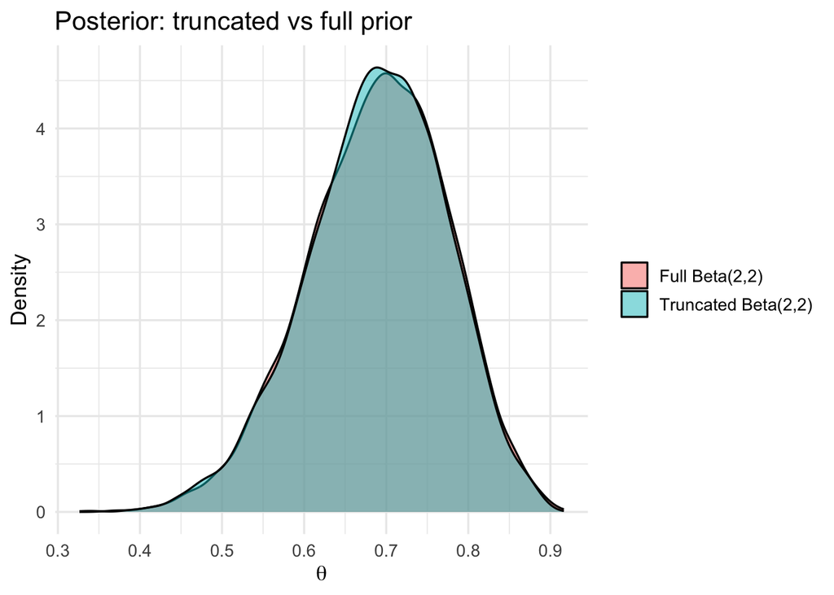

```r
df_plot <- data.frame(
  theta = c(samp_trunc, samp_full),
  Prior = rep(c("Truncated Beta(2,2)", "Full Beta(2,2)"), each = 1e4)
)
ggplot(df_plot, aes(x = theta, fill = Prior)) +
  geom_density(alpha = 0.5) +
  labs(title = "Posterior: truncated vs full prior",
       x = expression(theta), y = "Density") +
  theme_minimal(base_size = 13) +
  theme(legend.title = element_blank())
```

## Exercise 2: Metropolis by hand (Dutch Railways)

> Back to NS signal failures with prior Gamma(2, 0.5) and data $y = (2, 0, 3, 1)$. Pretend you’ve forgotten that the conjugate posterior is Gamma(8, 4.5). Build a tiny Metropolis sampler instead and compare.

**Exercise**

1. Implement a Metropolis sampler for $\lambda > 0$ with a Normal proposal centred at the current value (e.g. SD = 0.5). Use the **unnormalised** posterior $f(\lambda) \cdot L(y \mid \lambda)$ in the acceptance ratio.
2. Run 5,000 iterations, discard the first 1,000 as burn-in.
3. Compare your sampled mean and 95% ETI to the analytic posterior Gamma(8, 4.5).
4. Produce a trace plot. Does the chain look like a “hairy caterpillar”?

**Solution**

```r
set.seed(2026)

y <- c(2, 0, 3, 1)

log_post <- function(lambda) {
  if (lambda <= 0) return(-Inf)
  dgamma(lambda, shape = 2, rate = 0.5, log = TRUE) +
    sum(dpois(y, lambda, log = TRUE))
}

n_iter   <- 5000
lambda   <- numeric(n_iter)
lambda[1] <- 1            # starting value
accepts  <- 0

for (t in 2:n_iter) {
  proposal <- rnorm(1, mean = lambda[t - 1], sd = 0.5)
  log_a <- log_post(proposal) - log_post(lambda[t - 1])
  if (log(runif(1)) < log_a) {
    lambda[t] <- proposal
    accepts   <- accepts + 1
  } else {
    lambda[t] <- lambda[t - 1]
  }
}

cat("Acceptance rate:", round(accepts / (n_iter - 1), 3), "\n")
```

```
Acceptance rate: 0.742
```

```r
post <- lambda[1001:n_iter]                       # burn-in
cat("MCMC mean :", round(mean(post), 3), "\n")
```

```
MCMC mean : 1.77
```

```r
cat("Analytic  :", round(8 / 4.5, 3), "\n")
```

```
Analytic  : 1.778
```

```r
cat("MCMC 95% ETI:", round(quantile(post, c(.025, .975)), 3), "\n")
```

```
MCMC 95% ETI: 0.756 3.145
```

```r
cat("Analytic   :", round(qgamma(c(.025, .975), 8, 4.5), 3), "\n")
```

```
Analytic   : 0.768 3.205
```

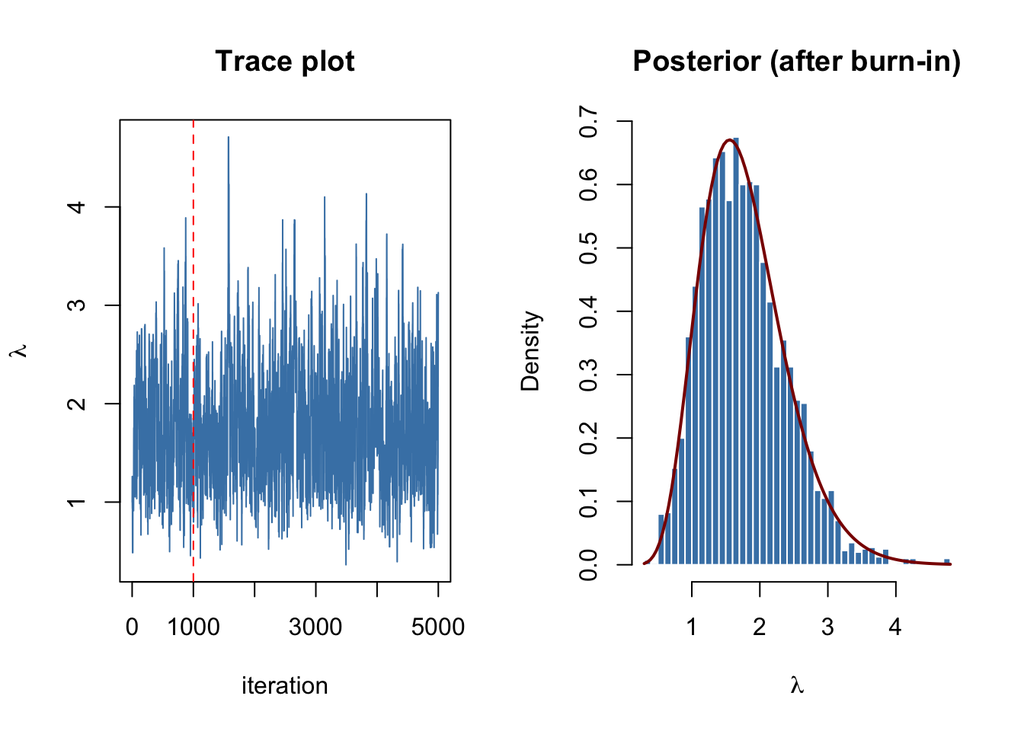

```r
par(mfrow = c(1, 2))
plot(lambda, type = "l", col = "steelblue",
     xlab = "iteration", ylab = expression(lambda),
     main = "Trace plot")
abline(v = 1000, col = "red", lty = 2)
hist(post, breaks = 40, probability = TRUE, col = "steelblue",
     border = "white", main = "Posterior (after burn-in)",
     xlab = expression(lambda))
curve(dgamma(x, 8, 4.5), add = TRUE, col = "darkred", lwd = 2)
```

```r
par(mfrow = c(1, 1))
```

The MCMC mean and ETI should sit very close to the analytic Gamma(8, 4.5) values — same posterior, two different routes.

**Next lecture (June 15):** Lecture 5 puts the posterior to work — point estimates, credible intervals, posterior prediction, prior + posterior predictive checks, and Bayes factors for hypothesis testing (Ch. 8 + Etz et al. 2018).